# Fairness in Housing Appraisal: Exploring Cook County Housing

**By:** Ava Haddock & Victor Cornejo

## Introduction

This project explored what can be learned from an extensive housing data set that is embedded in a dense social context in Cook County, Illinois.

The first part contains some basic exploratory data analysis (EDA) to understand the structure of the data. Which is done by adding new features to the dataset, and cleaning the data as well in the process.

The second part specifies and fits a linear model for the purpose of prediction. Finally, we analyzed the error of the model and brainstormed ways to improve the model's performance.

```python
import numpy as np

import pandas as pd
from pandas.api.types import CategoricalDtype

%matplotlib inline
import matplotlib.pyplot as plt
import seaborn as sns

import warnings
warnings.filterwarnings("ignore")

import zipfile
import os

from ds100_utils import run_linear_regression_test

# Plot settings
plt.rcParams['figure.figsize'] = (12, 9)
plt.rcParams['font.size'] = 12
```

# The Data

The data set consisted of over 500 thousand records from Cook County, Illinois, the county where Chicago is located. The data set we worked with had 61 features in total; the 62nd was sales price, which we predicted with linear regression in the second part of this project.

The data was split into training and test sets with 204,792 and 68,264 observations, respectively, but we only worked on the training set for this (the first) part of the project.

To begin, we extracted the data from the `cook_county_data.zip`.

```python
with zipfile.ZipFile('cook_county_data.zip') as item:
    item.extractall()
```

Loading the training data.

```python
training_data = pd.read_csv("cook_county_train.csv", index_col='Unnamed: 0')
```

As a good sanity check, we verified that the data shape matched the description.

```python
# 204792 observations and 62 features in training data
assert training_data.shape == (204792, 62)
# Sale Price is provided in the training data
assert 'Sale Price' in training_data.columns.values
```

Taking a quick look at all the starting columns in our training data.

```python
training_data.columns.values
```

```
array(['PIN', 'Property Class', 'Neighborhood Code', 'Land Square Feet',
       'Town Code', 'Apartments', 'Wall Material', 'Roof Material',
       'Basement', 'Basement Finish', 'Central Heating', 'Other Heating',
       'Central Air', 'Fireplaces', 'Attic Type', 'Attic Finish',
       'Design Plan', 'Cathedral Ceiling', 'Construction Quality',
       'Site Desirability', 'Garage 1 Size', 'Garage 1 Material',
       'Garage 1 Attachment', 'Garage 1 Area', 'Garage 2 Size',
       'Garage 2 Material', 'Garage 2 Attachment', 'Garage 2 Area',
       'Porch', 'Other Improvements', 'Building Square Feet',
       'Repair Condition', 'Multi Code', 'Number of Commercial Units',
       'Estimate (Land)', 'Estimate (Building)', 'Deed No.', 'Sale Price',
       'Longitude', 'Latitude', 'Census Tract',
       'Multi Property Indicator', 'Modeling Group', 'Age', 'Use',
       "O'Hare Noise", 'Floodplain', 'Road Proximity', 'Sale Year',
       'Sale Quarter', 'Sale Half-Year', 'Sale Quarter of Year',
       'Sale Month of Year', 'Sale Half of Year', 'Most Recent Sale',
       'Age Decade', 'Pure Market Filter', 'Garage Indicator',
       'Neigborhood Code (mapping)', 'Town and Neighborhood',
       'Description', 'Lot Size'], dtype=object)
```

```python
training_data['Description'][0]
```

```
'This property, sold on 09/14/2015, is a one-story houeshold located at 2950 S LYMAN ST.It has a total of 6 rooms, 3 of which are bedrooms, and 1.0 of which are bathrooms.'
```

```python
training_data.head(1)
```

|  | PIN | Property Class | Neighborhood Code | Land Square Feet | Town Code | Apartments | Wall Material | Roof Material | Basement | Basement Finish | ... | Sale Month of Year | Sale Half of Year | Most Recent Sale | Age Decade | Pure Market Filter | Garage Indicator | Neigborhood Code (mapping) | Town and Neighborhood | Description | Lot Size |
| --- | --- | --- | --- | --- | --- | --- | --- | --- | --- | --- | --- | --- | --- | --- | --- | --- | --- | --- | --- | --- | --- |
| 0 | 17294100610000 | 203 | 50 | 2500.0 | 76 | 0.0 | 2.0 | 1.0 | 1.0 | 3.0 | ... | 9 | 2 | 1.0 | 13.2 | 0 | 0.0 | 50 | 7650 | This property, sold on 09/14/2015, is a one-st... | 2500.0 |

1 rows × 62 columns

# Contextualizing the Data

To understand the background of our dataset before diving into a full-scale analysis, we should know that:

1.- Each row represents an instance of a property features in Cook County.

2.- This data was collected by realtors and real state agents as well as governmental institutions to predict the value of a porperty, the desirability of a neighborhood, to segregate, redline, etc.

3.- Certain variables in this data set contain information that either directly contains demographic information (data on people) or could when linked to other data sets. For example; The PIN, as it is unique to each property, and each property can be traced back to it's owners by looking at the purchase history. This, when linked to the Town/Neighborhood code can give us a demographic relationshio to the person that owns/inhabits the property.

4.- Most importantly, when looking at our data we should remember that we are looking at information that is made by people.

# Exploratory Data Analysis

This data set was collected by the [Cook County Assessor's Office](https://datacatalog.cookcountyil.gov/Property-Taxation/Archive-Cook-County-Assessor-s-Residential-Sales-D/5pge-nu6u) in order to build a model to predict the monetary value of a home.

Note that we performed EDA on the **training data**.

### Sale Price

We began by examining the distribution of our target variable `SalePrice`. At the same time, we also took a look at some descriptive statistics of this variable. We used the following helper method `plot_distribution` that we used to visualize the distribution of the `SalePrice` using both the histogram and the box plot at the same time.

```python
def plot_distribution(data, label):
    fig, axs = plt.subplots(nrows=2)

    sns.distplot(
        data[label],
        ax=axs[0]
    )
    sns.boxplot(
        data[label],
        width=0.3,
        ax=axs[1],
        showfliers=False,
    )

    # Align axes
    spacer = np.max(data[label]) * 0.05
    xmin = np.min(data[label]) - spacer
    xmax = np.max(data[label]) + spacer
    axs[0].set_xlim((xmin, xmax))
    axs[1].set_xlim((xmin, xmax))

    # Remove some axis text
    axs[0].xaxis.set_visible(False)
    axs[0].yaxis.set_visible(False)
    axs[1].yaxis.set_visible(False)

    # Put the two plots together
    plt.subplots_adjust(hspace=0)
```

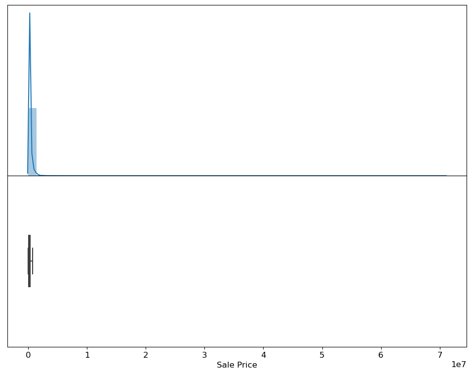

```python
plot_distribution(training_data, label='Sale Price')
```

## An Issue

The issue with the visualization above is that the Sale Price is highly skewed to the right. One way we could overcome such an issue would be by taking the log of the Sale Price. This would allow us to see the distribution of the Sale Price more clearly.

```python
training_data['Sale Price'].describe()
```

```
count    2.047920e+05
mean     2.451646e+05
std      3.628694e+05
min      1.000000e+00
25%      4.520000e+04
50%      1.750000e+05
75%      3.120000e+05
max      7.100000e+07
Name: Sale Price, dtype: float64
```

To zoom in on the visualization of most households, we focused only on a subset of `Sale Price`. In addition, it was helpful to apply a log transformation to `Sale Price`. Here, we reassigned `training_data` to a new dataframe that is the same as the original one **except with the following changes**:

- `training_data` contains only households whose price is at least $500.
- `training_data` contains a new `Log Sale Price` column that contains the log-transformed sale prices.

**Note**: This also implies that our target variable in the model was the log transformed sale prices from the column `Log Sale Price`.

```python
training_data = training_data[training_data['Sale Price'] >= 500]
training_data['Log Sale Price'] = np.log(training_data['Sale Price'])
training_data.head(1)
```

|  | PIN | Property Class | Neighborhood Code | Land Square Feet | Town Code | Apartments | Wall Material | Roof Material | Basement | Basement Finish | ... | Sale Half of Year | Most Recent Sale | Age Decade | Pure Market Filter | Garage Indicator | Neigborhood Code (mapping) | Town and Neighborhood | Description | Lot Size | Log Sale Price |
| --- | --- | --- | --- | --- | --- | --- | --- | --- | --- | --- | --- | --- | --- | --- | --- | --- | --- | --- | --- | --- | --- |
| 1 | 13272240180000 | 202 | 120 | 3780.0 | 71 | 0.0 | 2.0 | 1.0 | 1.0 | 1.0 | ... | 1 | 1.0 | 9.6 | 1 | 1.0 | 120 | 71120 | This property, sold on 05/23/2018, is a one-st... | 3780.0 | 12.560244 |

1 rows × 63 columns

We then created a new distribution plot on the log-transformed sale price.

```python
training_data['Sale Price'].head(1)
```

```
1    285000
Name: Sale Price, dtype: int64
```

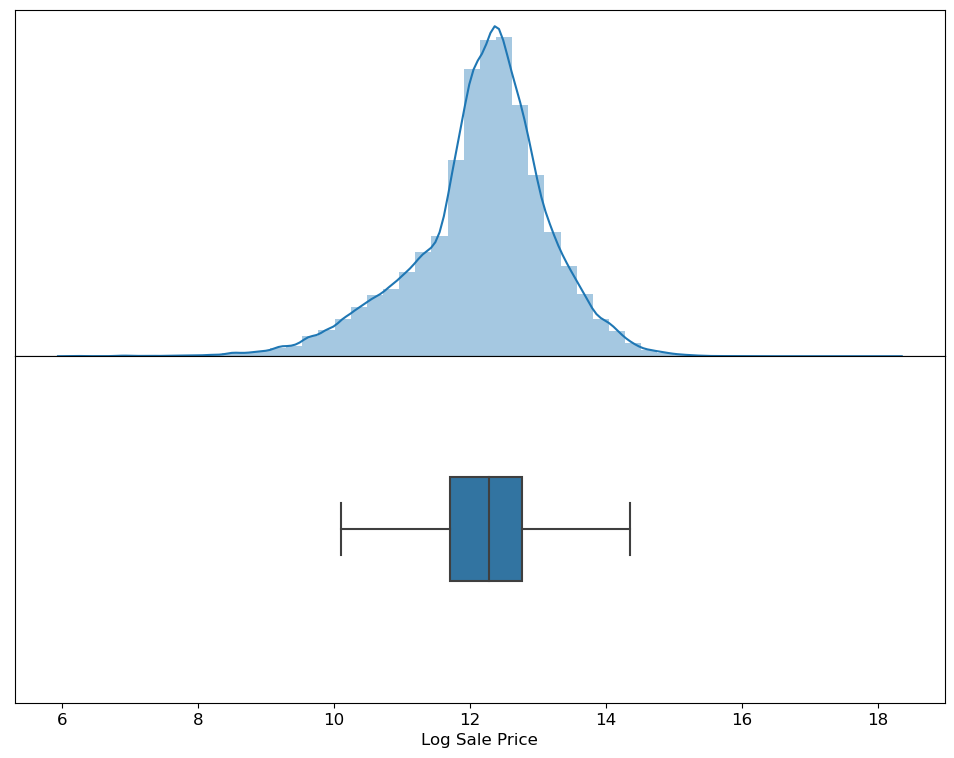

```python
plot_distribution(training_data, label='Log Sale Price');
```

```python
training_data['Log Sale Price'].describe()
```

```
count    168931.000000
mean         12.168227
std           0.999586
min           6.214608
25%          11.703546
50%          12.278393
75%          12.765688
max          18.078190
Name: Log Sale Price, dtype: float64
```

```python
training_data['Sale Price'].describe()
```

```
count    1.689310e+05
mean     2.972082e+05
std      3.796823e+05
min      5.000000e+02
25%      1.210000e+05
50%      2.150000e+05
75%      3.500000e+05
max      7.100000e+07
Name: Sale Price, dtype: float64
```

### Finding Patterns

Next, we wanted to see if there existed any correlation between `Log Sale Price` and the total area occupied by the household. The column `Building Square Feet` should do the trick -- it measures "(from the exterior) the total area, in square feet, occupied by the building".

Here we created a new column `Log Building Square Feet` in our `training_data` that contained the log transformed area occupied by each household.

```python
training_data['Log Building Square Feet'] = np.log(training_data['Building Square Feet'])
training_data.head(1)
```

|  | PIN | Property Class | Neighborhood Code | Land Square Feet | Town Code | Apartments | Wall Material | Roof Material | Basement | Basement Finish | ... | Most Recent Sale | Age Decade | Pure Market Filter | Garage Indicator | Neigborhood Code (mapping) | Town and Neighborhood | Description | Lot Size | Log Sale Price | Log Building Square Feet |
| --- | --- | --- | --- | --- | --- | --- | --- | --- | --- | --- | --- | --- | --- | --- | --- | --- | --- | --- | --- | --- | --- |
| 1 | 13272240180000 | 202 | 120 | 3780.0 | 71 | 0.0 | 2.0 | 1.0 | 1.0 | 1.0 | ... | 1.0 | 9.6 | 1 | 1.0 | 120 | 71120 | This property, sold on 05/23/2018, is a one-st... | 3780.0 | 12.560244 | 6.904751 |

1 rows × 64 columns

Continuing from the previous part, as we explored the data set, we still ran into more outliers that prevented us from creating a clear visualization or capturing the trend of the majority of the houses.

```python
def remove_outliers(data, variable, lower=-np.inf, upper=np.inf):
    """
    Input:
      data (data frame): the table to be filtered
      variable (string): the column with numerical outliers
      lower (numeric): observations with values lower than this will be removed
      upper (numeric): observations with values higher than this will be removed

    Output:
      a data frame with outliers removed

    Note: This function should not change mutate the contents of data.
    """
    return data[(data[variable] > lower) & (data[variable] < upper)]
```

# Feature Engineering

In this section we employed a few feature engineering techniques.

**Bedrooms**

Starting simple, we extracted the total number of bedrooms as our first feature for the model. The `Bedrooms` column doesn't actually exist in the original dataframe. Instead, it is part of the `Description` column.

We wrote a function `add_total_bedrooms(data)` that returned a copy of `data` with an additional column called `Bedrooms` that contained the total number of bedrooms (as integers) for each house. **Treating missing values as zeros if necessary**.

```python
def add_total_bedrooms(data):
    """
    Input:
      data (data frame): a data frame containing at least the Description column.
    """
    with_rooms = data.copy()
    with_rooms['Bedrooms'] = with_rooms['Description'].str.extract('(\d) of which are bedrooms').fillna(0).astype(int)
    return with_rooms

training_data = add_total_bedrooms(training_data)
```

```python
training_data['Bedrooms'].value_counts()
```

```
3    83264
4    44405
2    30618
5     7936
6     1910
1      467
7      223
8       80
9       22
0        6
Name: Bedrooms, dtype: int64
```

### Visualizing our findings

We then opted for a visualization that clearly showed if there existed an association between `Bedrooms` and `Log Sale Price`. We defined a good visualization as one that would:

- Avoid overplotting.
- Have clearly labeled axes and succinct title.
- Convey the strength of the correlation between the sale price and the number of rooms.

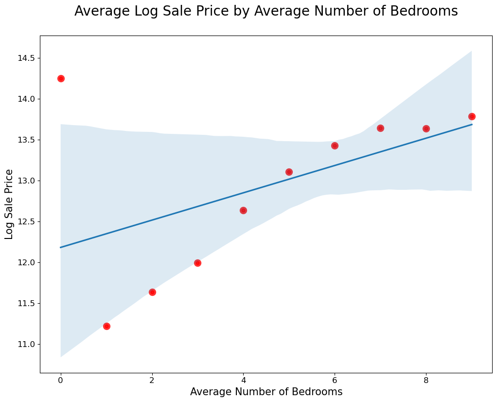

```python
average_bedrooms = training_data.groupby('Bedrooms').mean()
sns.regplot(x=average_bedrooms.index, y=average_bedrooms['Log Sale Price'], scatter_kws={'lw': 5, 'color': 'red'})
plt.xlabel('Average Number of Bedrooms', fontsize=15)
plt.ylabel('Log Sale Price', fontsize=15)
plt.title('Average Log Sale Price by Average Number of Bedrooms\n', fontsize=20)
```

## More Visualizations

Now, we could take a look at the relationship between neighborhood and sale prices of the houses in our data set. However, since we didn't have the actual names for the neighborhoods. Instead we used a similar column `Neighborhood Code` (which is a numerical encoding of the actual neighborhoods by the Assessment office).

Before creating any visualization, we quickly inspected how many different neighborhoods we were dealing with.

For this, we assigned the variable `num_neighborhoods` with the total number of neighborhoods in our `training_data`.

```python
num_neighborhoods = training_data['Neighborhood Code'].nunique()
num_neighborhoods
```

```
193
```

If we tried directly plotting the distribution of `Log Sale Price` for all of the households in each neighborhood using the `plot_categorical` function from the next cell, we would get the following visualization.

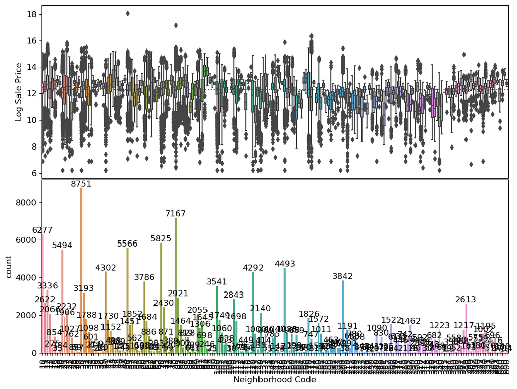

```python
def plot_categorical(neighborhoods):
    fig, axs = plt.subplots(nrows=2)

    sns.boxplot(
        x='Neighborhood Code',
        y='Log Sale Price',
        data=neighborhoods,
        ax=axs[0],
    )

    sns.countplot(
        x='Neighborhood Code',
        data=neighborhoods,
        ax=axs[1],
    )

    # Draw median price
    axs[0].axhline(
        y=training_data['Log Sale Price'].median(),
        color='red',
        linestyle='dotted'
    )

    # Label the bars with counts
    for patch in axs[1].patches:
        x = patch.get_bbox().get_points()[:, 0]
        y = patch.get_bbox().get_points()[1, 1]
        axs[1].annotate(f'{int(y)}', (x.mean(), y), ha='center', va='bottom')

    # Format x-axes
    axs[1].set_xticklabels(axs[1].xaxis.get_majorticklabels(), rotation=90)
    axs[0].xaxis.set_visible(False)

    # Narrow the gap between the plots
    plt.subplots_adjust(hspace=0.01)

plot_categorical(training_data[['Neighborhood Code', 'Log Sale Price']])
```

And... it looked like we ran into the problem of overplotting. Again!

The graph was overplotted because **there were actually quite a few neighborhoods in our dataset** For the clarity of our visualization, we had to zoom in again on a few of them. The reason for this is our visualization would become quite cluttered with a super dense x-axis.

For this, we assigned the variable `in_top_20_neighborhoods` to a copy of `training_data` that contains only top 20 neighborhoods with the most number of houses.

```python
top_20 = training_data.groupby('Neighborhood Code').count().sort_values('PIN', ascending=False).iloc[:20].index
in_top_20_neighborhoods = training_data[training_data['Neighborhood Code'].isin(top_20)]
in_top_20_neighborhoods.head()
```

|  | PIN | Property Class | Neighborhood Code | Land Square Feet | Town Code | Apartments | Wall Material | Roof Material | Basement | Basement Finish | ... | Age Decade | Pure Market Filter | Garage Indicator | Neigborhood Code (mapping) | Town and Neighborhood | Description | Lot Size | Log Sale Price | Log Building Square Feet | Bedrooms |
| --- | --- | --- | --- | --- | --- | --- | --- | --- | --- | --- | --- | --- | --- | --- | --- | --- | --- | --- | --- | --- | --- |
| 1 | 13272240180000 | 202 | 120 | 3780.0 | 71 | 0.0 | 2.0 | 1.0 | 1.0 | 1.0 | ... | 9.6 | 1 | 1.0 | 120 | 71120 | This property, sold on 05/23/2018, is a one-st... | 3780.0 | 12.560244 | 6.904751 | 3 |
| 4 | 31361040550000 | 202 | 120 | 8400.0 | 32 | 0.0 | 3.0 | 1.0 | 2.0 | 3.0 | ... | 6.3 | 1 | 1.0 | 120 | 32120 | This property, sold on 06/10/2016, is a one-st... | 8400.0 | 10.025705 | 6.855409 | 2 |
| 8 | 13232040260000 | 205 | 70 | 3100.0 | 71 | 0.0 | 2.0 | 2.0 | 1.0 | 3.0 | ... | 10.0 | 1 | 1.0 | 70 | 7170 | This property, sold on 08/25/2016, is a two-st... | 3100.0 | 13.422468 | 7.636270 | 4 |
| 10 | 19074270080000 | 202 | 380 | 3750.0 | 72 | 0.0 | 1.0 | 1.0 | 2.0 | 3.0 | ... | 7.4 | 1 | 1.0 | 380 | 72380 | This property, sold on 05/01/2017, is a one-st... | 3750.0 | 11.695247 | 6.841615 | 2 |
| 11 | 15083050330000 | 203 | 20 | 5092.0 | 31 | 0.0 | 2.0 | 1.0 | 1.0 | 1.0 | ... | 5.8 | 1 | 1.0 | 20 | 3120 | This property, sold on 04/29/2014, is a one-st... | 5092.0 | 11.184421 | 6.911747 | 3 |

5 rows × 65 columns

This time we created another visualization of the distribution of sale price within in each neighborhood again, but this time with a narrower focus!

However, the findings hint that there is no correlation as the neighborhood Code cannot provide a linearly related value to the log price of the houses...

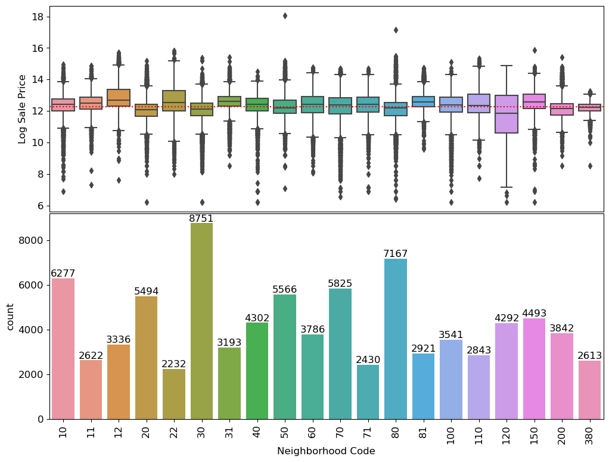

```python
plot_categorical(neighborhoods=in_top_20_neighborhoods)
#plt.title('Distribution of Log Sale Price within Top 20 Neighborhoods')
```

### However

One way we could deal with the lack of data from some neighborhoods was by creating a new feature that binned neighborhoods together. Categorizing our neighborhoods in a crude way: we took the top 3 neighborhoods measured by median `Log Sale Price` and identified them as "expensive neighborhoods"; the other neighborhoods were not marked.

We then wrote a function that returned a list of the neighborhood codes of the top `n` most pricy neighborhoods as measured by our choice of aggregating function.

```python
def find_expensive_neighborhoods(data, n=3, metric=np.median):
    """
    Input:
      data (data frame): should contain at least a string-valued 'Neighborhood Code'
        and a numeric 'Sale Price' column
      n (int): the number of top values desired
      metric (function): function used for aggregating the data in each neighborhood.
        for example, np.median for median prices

    Output:
      a list of the the neighborhood codes of the top n highest-priced neighborhoods as measured by the metric function
    """
    neighborhoods = data.groupby('Neighborhood Code').agg({'Log Sale Price': metric}).sort_values('Log Sale Price', ascending=False).iloc[:n].index
    return list(neighborhoods)

    # This makes sure the final list contains the generic int type used in Python3, not specific ones used in numpy.
    return [int(code) for code in neighborhoods]

expensive_neighborhoods = find_expensive_neighborhoods(training_data, 3, np.median)
expensive_neighborhoods
```

```
[44, 94, 93]
```

We now had a list of neighborhoods we've deemed as higher-priced than others. We used that information to write a function `add_expensive_neighborhood` that add a column `in_expensive_neighborhood` which took on the value 1 if the house was part of `expensive_neighborhoods` and the value 0 otherwise. This type of variable is known as an **indicator variable**.

```python
expensive_neighborhoods
```

```
[44, 94, 93]
```

```python
def add_in_expensive_neighborhood(data, neighborhoods):
    """
    Input:
      data (data frame): a data frame containing a 'Neighborhood Code' column with values
        found in the codebook
      neighborhoods (list of strings): strings should be the names of neighborhoods
        pre-identified as expensive
    Output:
      data frame identical to the input with the addition of a binary
      in_expensive_neighborhood column
    """
    data['in_expensive_neighborhood'] = data['Neighborhood Code'].isin(neighborhoods).astype(int)
    return data

expensive_neighborhoods = find_expensive_neighborhoods(training_data, 3, np.median)
training_data = add_in_expensive_neighborhood(training_data, expensive_neighborhoods)
training_data
```

|  | PIN | Property Class | Neighborhood Code | Land Square Feet | Town Code | Apartments | Wall Material | Roof Material | Basement | Basement Finish | ... | Pure Market Filter | Garage Indicator | Neigborhood Code (mapping) | Town and Neighborhood | Description | Lot Size | Log Sale Price | Log Building Square Feet | Bedrooms | in_expensive_neighborhood |
| --- | --- | --- | --- | --- | --- | --- | --- | --- | --- | --- | --- | --- | --- | --- | --- | --- | --- | --- | --- | --- | --- |
| 1 | 13272240180000 | 202 | 120 | 3780.0 | 71 | 0.0 | 2.0 | 1.0 | 1.0 | 1.0 | ... | 1 | 1.0 | 120 | 71120 | This property, sold on 05/23/2018, is a one-st... | 3780.0 | 12.560244 | 6.904751 | 3 | 0 |
| 2 | 25221150230000 | 202 | 210 | 4375.0 | 70 | 0.0 | 2.0 | 1.0 | 2.0 | 3.0 | ... | 1 | 1.0 | 210 | 70210 | This property, sold on 02/18/2016, is a one-st... | 4375.0 | 9.998798 | 6.810142 | 3 | 0 |
| 3 | 10251130030000 | 203 | 220 | 4375.0 | 17 | 0.0 | 3.0 | 1.0 | 1.0 | 3.0 | ... | 1 | 1.0 | 220 | 17220 | This property, sold on 07/23/2013, is a one-st... | 4375.0 | 12.323856 | 7.068172 | 3 | 0 |
| 4 | 31361040550000 | 202 | 120 | 8400.0 | 32 | 0.0 | 3.0 | 1.0 | 2.0 | 3.0 | ... | 1 | 1.0 | 120 | 32120 | This property, sold on 06/10/2016, is a one-st... | 8400.0 | 10.025705 | 6.855409 | 2 | 0 |
| 6 | 30314240080000 | 203 | 181 | 10890.0 | 37 | 0.0 | 1.0 | 1.0 | 1.0 | 3.0 | ... | 1 | 1.0 | 181 | 37181 | This property, sold on 10/26/2017, is a one-st... | 10890.0 | 11.512925 | 7.458186 | 4 | 0 |
| ... | ... | ... | ... | ... | ... | ... | ... | ... | ... | ... | ... | ... | ... | ... | ... | ... | ... | ... | ... | ... | ... |
| 204787 | 25163010260000 | 202 | 321 | 4375.0 | 72 | 0.0 | 2.0 | 1.0 | 1.0 | 1.0 | ... | 1 | 1.0 | 321 | 72321 | This property, sold on 07/23/2014, is a one-st... | 4375.0 | 10.521372 | 6.813445 | 2 | 0 |
| 204788 | 5063010090000 | 204 | 21 | 16509.0 | 23 | 0.0 | 1.0 | 1.0 | 1.0 | 1.0 | ... | 1 | 1.0 | 21 | 2321 | This property, sold on 03/27/2019, is a one-st... | 16509.0 | 12.323856 | 7.603399 | 4 | 0 |
| 204789 | 16333020150000 | 202 | 90 | 3810.0 | 15 | 0.0 | 2.0 | 1.0 | 1.0 | 1.0 | ... | 1 | 1.0 | 90 | 1590 | This property, sold on 01/31/2014, is a one-st... | 3810.0 | 11.813030 | 6.815640 | 3 | 0 |
| 204790 | 9242030500000 | 203 | 80 | 6650.0 | 22 | 0.0 | 2.0 | 1.0 | 1.0 | 3.0 | ... | 1 | 1.0 | 80 | 2280 | This property, sold on 02/22/2018, is a one-st... | 6650.0 | 12.879017 | 7.092574 | 3 | 0 |
| 204791 | 19102030080000 | 203 | 30 | 2500.0 | 72 | 0.0 | 1.0 | 1.0 | 1.0 | 3.0 | ... | 1 | 0.0 | 30 | 7230 | This property, sold on 04/22/2014, is a one-st... | 2500.0 | 11.736069 | 6.946976 | 2 | 0 |

168931 rows × 66 columns

## Adding Features

We decided to take a closer look at the `Roof Material` feature of the dataset and examined how we could incorporate categorical features into our linear model.

Looking at `codebook.txt` carefully, we could see that the Assessor's Office used the following mapping for the numerical values in the `Roof Material` column.

[output not shown]

```python
training_data['Roof Material'].value_counts()
```

```
1.0    160760
2.0      3774
4.0      1620
5.0      1201
6.0       841
3.0       735
Name: Roof Material, dtype: int64
```

```python
def substitute_roof_material(data):
    """
    Input:
      data (data frame): a data frame containing a 'Roof Material' column.  Its values
                         should be limited to those found in the codebook
    Output:
      data frame identical to the input except with a refactored 'Roof Material' column
    """
    data['Roof Material'] = data['Roof Material'].replace({
        1: 'Shingle/Asphalt',
        2: 'Tar&Gravel',
        3: 'Slate',
        4: 'Shake',
        5: 'Tile',
        6: 'Other',
    })

    return data

training_data = substitute_roof_material(training_data)
training_data['Roof Material'].value_counts()
```

```
Shingle/Asphalt    160760
Tar&Gravel           3774
Shake                1620
Tile                 1201
Other                 841
Slate                 735
Name: Roof Material, dtype: int64
```

### Hot Encoding

#### An Important Note on One Hot Encoding

Unfortunately, simply fixing these missing values wasn't sufficient for using `Roof Material` in our model. Since `Roof Material` is a categorical variable, we will have to one-hot-encode the data.

So, we defined the following function `ohe_roof_material` that returned a dataframe with the new column one-hot-encoded on the roof material of the household.

Checking our Matrix Dimensions:

```python
training_data.shape
```

```
(168931, 66)
```

```python
from sklearn.preprocessing import OneHotEncoder

def ohe_roof_material(data):
    """
    One-hot-encodes roof material.  New columns are of the form x0_MATERIAL.
    """
    data = data.copy()
    ohe = OneHotEncoder(categories=[['Shingle/Asphalt', 'Tar&Gravel', 'Slate', 'Shake', 'Tile', 'Other']])
    ohe.fit(data[['Roof Material']])
    ohe_data = ohe.transform(data[['Roof Material']]).toarray()
    ohe_data = pd.DataFrame(ohe_data, columns=['Roof Material_' + material for material in ohe.categories_[0]])
    data = pd.concat([data, ohe_data.set_index(data.index)], axis = 1)
    return data

training_data = ohe_roof_material(training_data)
training_data.filter(regex='^Roof Material_').head(10)
```

|  | Roof Material_Shingle/Asphalt | Roof Material_Tar&Gravel | Roof Material_Slate | Roof Material_Shake | Roof Material_Tile | Roof Material_Other |
| --- | --- | --- | --- | --- | --- | --- |
| 1 | 1.0 | 0.0 | 0.0 | 0.0 | 0.0 | 0.0 |
| 2 | 1.0 | 0.0 | 0.0 | 0.0 | 0.0 | 0.0 |
| 3 | 1.0 | 0.0 | 0.0 | 0.0 | 0.0 | 0.0 |
| 4 | 1.0 | 0.0 | 0.0 | 0.0 | 0.0 | 0.0 |
| 6 | 1.0 | 0.0 | 0.0 | 0.0 | 0.0 | 0.0 |
| 7 | 1.0 | 0.0 | 0.0 | 0.0 | 0.0 | 0.0 |
| 8 | 0.0 | 1.0 | 0.0 | 0.0 | 0.0 | 0.0 |
| 9 | 1.0 | 0.0 | 0.0 | 0.0 | 0.0 | 0.0 |
| 10 | 1.0 | 0.0 | 0.0 | 0.0 | 0.0 | 0.0 |
| 11 | 1.0 | 0.0 | 0.0 | 0.0 | 0.0 | 0.0 |

```python
training_data.head()
```

|  | PIN | Property Class | Neighborhood Code | Land Square Feet | Town Code | Apartments | Wall Material | Roof Material | Basement | Basement Finish | ... | Log Sale Price | Log Building Square Feet | Bedrooms | in_expensive_neighborhood | Roof Material_Shingle/Asphalt | Roof Material_Tar&Gravel | Roof Material_Slate | Roof Material_Shake | Roof Material_Tile | Roof Material_Other |
| --- | --- | --- | --- | --- | --- | --- | --- | --- | --- | --- | --- | --- | --- | --- | --- | --- | --- | --- | --- | --- | --- |
| 1 | 13272240180000 | 202 | 120 | 3780.0 | 71 | 0.0 | 2.0 | Shingle/Asphalt | 1.0 | 1.0 | ... | 12.560244 | 6.904751 | 3 | 0 | 1.0 | 0.0 | 0.0 | 0.0 | 0.0 | 0.0 |
| 2 | 25221150230000 | 202 | 210 | 4375.0 | 70 | 0.0 | 2.0 | Shingle/Asphalt | 2.0 | 3.0 | ... | 9.998798 | 6.810142 | 3 | 0 | 1.0 | 0.0 | 0.0 | 0.0 | 0.0 | 0.0 |
| 3 | 10251130030000 | 203 | 220 | 4375.0 | 17 | 0.0 | 3.0 | Shingle/Asphalt | 1.0 | 3.0 | ... | 12.323856 | 7.068172 | 3 | 0 | 1.0 | 0.0 | 0.0 | 0.0 | 0.0 | 0.0 |
| 4 | 31361040550000 | 202 | 120 | 8400.0 | 32 | 0.0 | 3.0 | Shingle/Asphalt | 2.0 | 3.0 | ... | 10.025705 | 6.855409 | 2 | 0 | 1.0 | 0.0 | 0.0 | 0.0 | 0.0 | 0.0 |
| 6 | 30314240080000 | 203 | 181 | 10890.0 | 37 | 0.0 | 1.0 | Shingle/Asphalt | 1.0 | 3.0 | ... | 11.512925 | 7.458186 | 4 | 0 | 1.0 | 0.0 | 0.0 | 0.0 | 0.0 | 0.0 |

5 rows × 72 columns

```python
training_data.shape
```

```
(168931, 72)
```

## That's it for Part I

In the second part, we focused on building a linear model to predict home prices. In this part we considered what is in our data set, what it could be used for, and engineered some features that should be useful for prediction. Creating a house-pricing model for Cook County has some challenging social implications to think, don't you think?